# Reproducible analysis pipelines with `{targets}`

Rladies Sydney

Olivia Angelin-Bonnet

The New Zealand Institute for Plant and Food Research Ltd

7 April 2025

## Hi! I’m Olivia :)

[figure not shown]

Location of Le Pont-de-Beauvoisin on a map of France

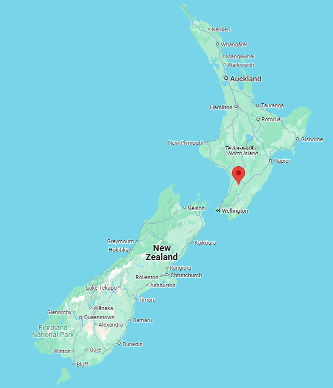

Location of Palmerston North on a map of New Zealand

## Hi! I’m Olivia :)

Statistical scientist at Plant & Food Research, working on omics analyses and multi-omics integration

**Multivariate analyses**

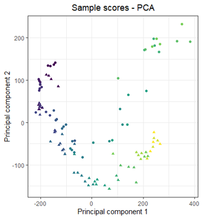

**Visualisations**

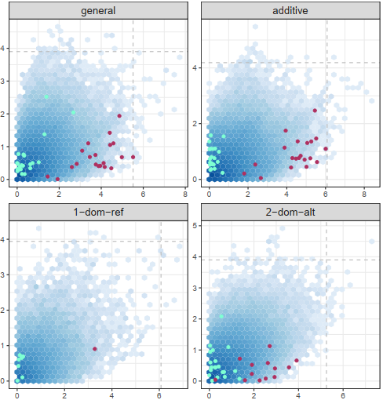

**R packages**

[figure not shown]

## Developing complex analyses in R

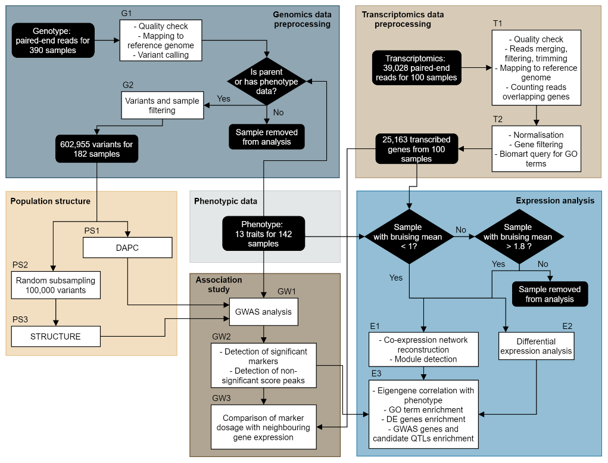

Schema of the analysis for one of my thesis chapters

## Developing complex analyses in R

Project folder:

```
thesis/chapter4_code
├── genomics_data_analysis
│   ├── 00_genomics_wrangling.Rmd
│   ├── 01_genomics_filtering.Rmd
│   └── 02_genomics_eda.Rmd
└── transcriptomics_data_analysis
|   ├── 00_transcriptomics_wrangling.Rmd
|   ├── 01_transcriptomics_normalisation.Rmd
|   ├── 02_transcriptomics_diff_expr.Rmd
|   └── 03_transcriptomics_wgcna.Rmd
...
```

- Input data has changed; what do I need to re-run?
- In which order do I need to run these scripts?
- I want to change one line of text in my report, how long will it take to re-generate the output?

## Developing complex analyses in R

Solution: Turn your scripts into pipelines with `{targets}`!

[figure not shown]

- automatic detection of steps dependencies
- 1-command execution
- automatic caching
- automatic detection of changes in data and/or code

## Let’s learn about `{targets}`

… through an example!

`palmerpenguins` dataset: size measurements for three penguin species observed in the Palmer Archipelago (Antarctica)

## To go further

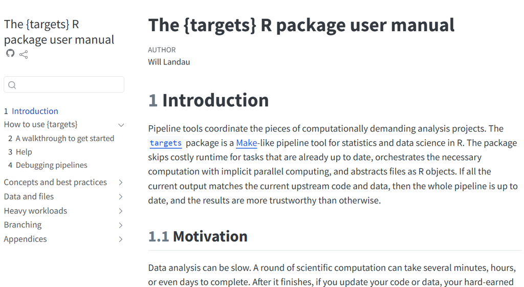

https://books.ropensci.org/targets/

## Aside – more about setting up R projects

- previous talk: “Setting up a reproducible data analysis project in R–featuring GitHub, `{renv}`, `{targets}` and more”
- see the [slides](https://nzsa-ecssn-2024-seminar-slides.netlify.app/), [recording](https://youtu.be/DTpcGgdL-cc), or [blog post](https://olivia-angelin-bonnet.netlify.app/blog/2024-08-20-setting-up-r-project/) ☺️

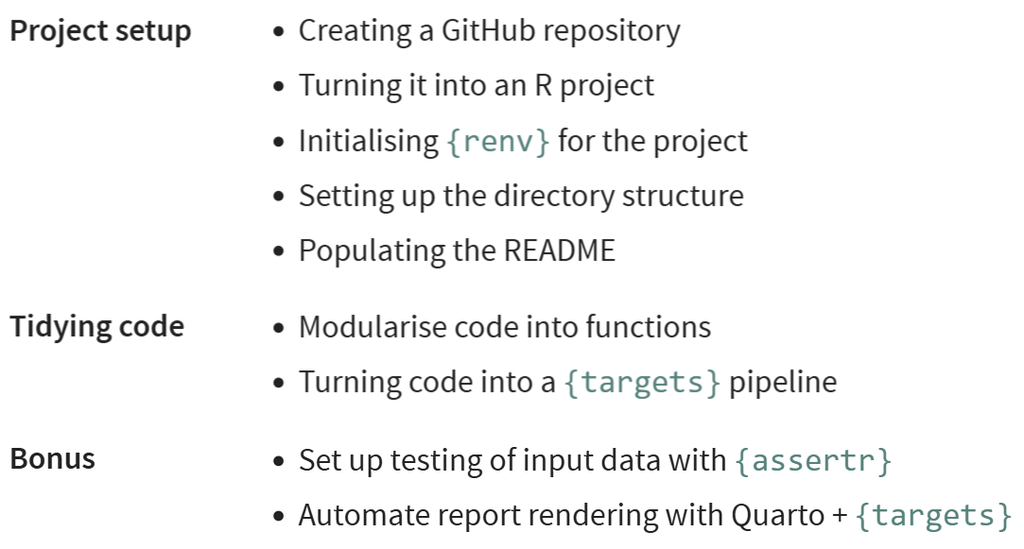

# Let’s code!

## I have written some code…

```r
library(tidyverse)
library(janitor)
library(ggbeeswarm)
library(here)

# Reading and cleaning data
penguins_df <- read_csv(here("data/penguins_raw.csv"), show_col_types = FALSE) |>
  clean_names() |>
  mutate(
    species = word(species, 1),
    year = year(date_egg),
    sex = str_to_lower(sex),
    year = as.integer(year),
    body_mass_g = as.integer(body_mass_g),
    across(where(is.character), as.factor)
  ) |>
  select(
    species,
    island,
    year,
    sex,
    body_mass_g,
    bill_length_mm = culmen_length_mm,
    bill_depth_mm = culmen_depth_mm,
    flipper_length_mm
  ) |>
  drop_na()

## Violin plot of body mass per species and sex
penguins_df |>
  ggplot(aes(x = species, colour = sex, fill = sex, y = body_mass_g)) +
  geom_violin(alpha = 0.3, scale = "width") +
  geom_quasirandom(dodge.width = 0.9) +
  scale_colour_brewer(palette = "Set1") +
  scale_fill_brewer(palette = "Set1") +
  theme_minimal()

## Violin plot of flipper length per species and sex
penguins_df |>
  ggplot(aes(x = species, colour = sex, fill = sex, y = flipper_length_mm)) +
  geom_violin(alpha = 0.3, scale = "width") +
  geom_quasirandom(dodge.width = 0.9) +
  scale_colour_brewer(palette = "Set1") +
  scale_fill_brewer(palette = "Set1") +
  theme_minimal()

## Scatter plot of bill length vs depth, with species and sex
penguins_df |>
  ggplot(aes(x = bill_length_mm, y = bill_depth_mm, colour = species, shape = sex)) +
  geom_point() +
  scale_colour_brewer(palette = "Set2") +
  theme_minimal()
```

## I have written some code…

Good start, but often:

- many more steps in the analysis $\rightarrow$ script becomes long and convoluted
- harder to get an overview of the analysis, and to find things
- don’t want to re-run all the code everytime I make a change

Let’s turn it into a `{targets}` pipeline!

## Step 1: Turn your code into functions

From:

```r
# Reading and cleaning data
penguins_df <- read_csv(
  here("data/penguins_raw.csv"),
  show_col_types = FALSE
) |>
  clean_names() |>
  mutate(
    species = word(species, 1),
    year = year(date_egg),
    sex = str_to_lower(sex),
    year = as.integer(year),
    body_mass_g = as.integer(body_mass_g),
    across(where(is.character), as.factor)
  ) |>
  select(
    ## all relevant columns
  ) |>
  drop_na()
```

To:

```r
read_data <- function(file) {
  readr::read_csv(
    file,
    show_col_types = FALSE
  ) |>
  janitor::clean_names() |>
  dplyr::mutate(
    species = stringr::word(species, 1),
    year = lubridate::year(date_egg),
    sex = stringr::str_to_lower(sex),
    year = as.integer(year),
    body_mass_g = as.integer(body_mass_g),
    dplyr::across(
      dplyr::where(is.character),
      as.factor
    )
  ) |>
  dplyr::select(
    ## all relevant columns
  ) |>
  tidyr::drop_na()
}
```

## Step 1: Turn your code into functions

Don’t forget to document your functions! (`{roxygen}`-style)

```r
#' Read and clean data
#'
#' Reads in the penguins data, renames and selects relevant columns. The
#' following transformations are applied to the data:
#' * only keep species common name
#' * extract observation year
#' * remove rows with missing values
#'
#' @param file Character, path to the penguins data .csv file.
#' @returns A tibble.
read_data <- function(file) {
  readr::read_csv(file, show_col_types = FALSE) |>
  janitor::clean_names() |>
  dplyr::mutate(
    ## modifying columns
  ) |>
  dplyr::select(
    ## all relevant columns
  ) |>
  tidyr::drop_na()
}
```

## Step 1: Turn your code into functions

Improved script:

```
R/helper_functions.R
```

```r
#' Read and clean data
#'
#' ...
read_data <- function(file) { ... }

#' Violin plot of variable per species and sex
#'
#' ...
violin_plot <- function(df, yvar) { ... }

#' Scatter plot of bill length vs depth
#'
#' ...
plot_bill_length_depth <- function(df) { ... }
```

```
analysis/first_script.R
```

```r
library(here)

source(here("R/helper_functions.R"))

penguins_df <- read_data(
  here("data/penguins_raw.csv")
)

body_mass_plot <- violin_plot(
  penguins_df,
  body_mass_g
)

flipper_length_plot <- violin_plot(
  penguins_df,
  flipper_length_mm
)

bill_scatterplot <- plot_bill_length_depth(
  penguins_df
)
```

## Step 2: Turn your main script into a `{targets}` pipeline!

From:

```r
library(here)

source(here("R/helper_functions.R"))

penguins_df <- read_data(here("data/penguins_raw.csv"))

body_mass_plot <- violin_plot(penguins_df, body_mass_g)

flipper_length_plot <- violin_plot(penguins_df, flipper_length_mm)

bill_scatterplot <- plot_bill_length_depth(penguins_df)
```

## Step 2: Turn your main script into a `{targets}` pipeline!

To:

```r
library(targets)
library(here)

source(here("R/helper_functions.R"))

list(
  tar_target(penguins_raw_file, here("data/penguins_raw.csv"), format = "file"),

  tar_target(penguins_df, read_data(penguins_raw_file)),

  tar_target(body_mass_plot, violin_plot(penguins_df, body_mass_g)),

  tar_target(flipper_length_plot, violin_plot(penguins_df, flipper_length_mm)),

  tar_target(bill_scatterplot, plot_bill_length_depth(penguins_df))
)
```

## Visualise your pipeline

In the console, run:

```r
targets::tar_visnetwork()
```

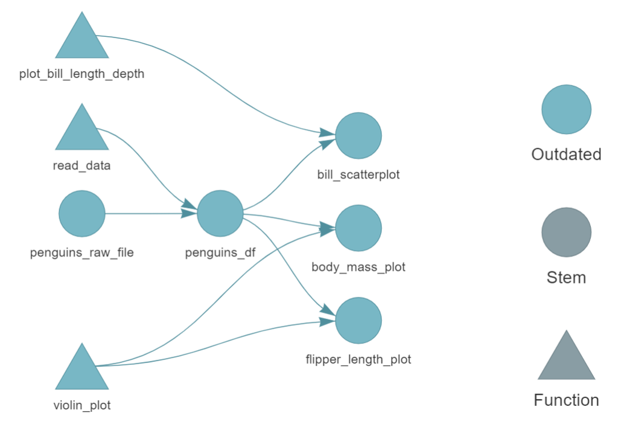

## Execute your pipeline

In the console, run:

```r
targets::tar_make()
```

```
here() starts at C:/Users/hrpoab/Desktop/GitHub/palmerpenguins_analysis
> dispatched target penguins_raw_file
o completed target penguins_raw_file [0 seconds]
> dispatched target penguins_df
o completed target penguins_df [0.85 seconds]
> dispatched target body_mass_plot
o completed target body_mass_plot [0.16 seconds]
> dispatched target bill_scatterplot
o completed target bill_scatterplot [0.02 seconds]
> dispatched target flipper_length_plot
o completed target flipper_length_plot [0.02 seconds]
> ended pipeline [1.31 seconds]
```

## Get the pipeline results

```r
targets::tar_read(bill_scatterplot)
```

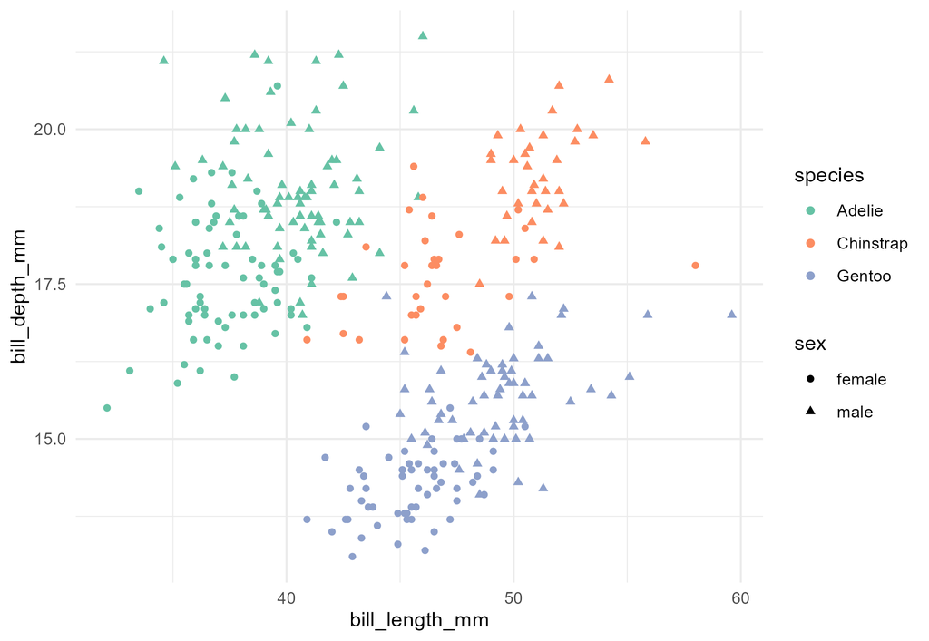

## After executing the pipeline

```r
targets::tar_visnetwork()
```

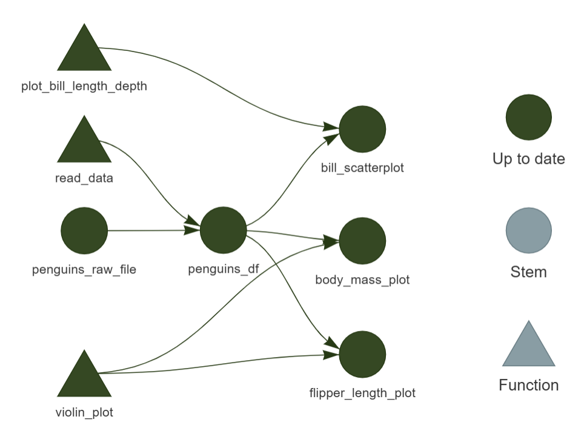

## After executing the pipeline

```r
targets::tar_make()
```

```
here() starts at C:/Users/HRPOAB/Desktop/GitHub/palmerpenguins_analysis
v skipped target penguins_raw_file
v skipped target penguins_df
v skipped target body_mass_plot
v skipped target bill_scatterplot
v skipped target flipper_length_plot
v skipped pipeline [0.1 seconds]
```

## Change in a step

> *Hi Olivia,*

> *Great work! Just a minor comment, could you change the colours in the bill length/depth scatter-plot? It’s hard to see the difference between the species.*

```
R/helper_functions.R
```

```r
plot_bill_length_depth <- function(df) {
  df |>
    ggplot2::ggplot(
      ggplot2::aes(
        x = bill_length_mm,
        y = bill_depth_mm,
        colour = species,
        shape = sex
        )
    ) +
    ggplot2::geom_point() +
    ggplot2::scale_colour_brewer(palette = "Set2") +
    ggplot2::theme_minimal()
}
```

## Change in a step

> *Hi Olivia,*

> *Great work! Just a minor comment, could you change the colours in the bill length/depth scatter-plot? It’s hard to see the difference between the species.*

```
R/helper_functions.R
```

```r
plot_bill_length_depth <- function(df) {
  df |>
    ggplot2::ggplot(
      ggplot2::aes(
        x = bill_length_mm,
        y = bill_depth_mm,
        colour = species,
        shape = sex
        )
    ) +
    ggplot2::geom_point() +
    ggplot2::scale_colour_brewer(palette = "Set1") +
    ggplot2::theme_minimal()
}
```

## Change in a step

```r
targets::tar_visnetwork()
```

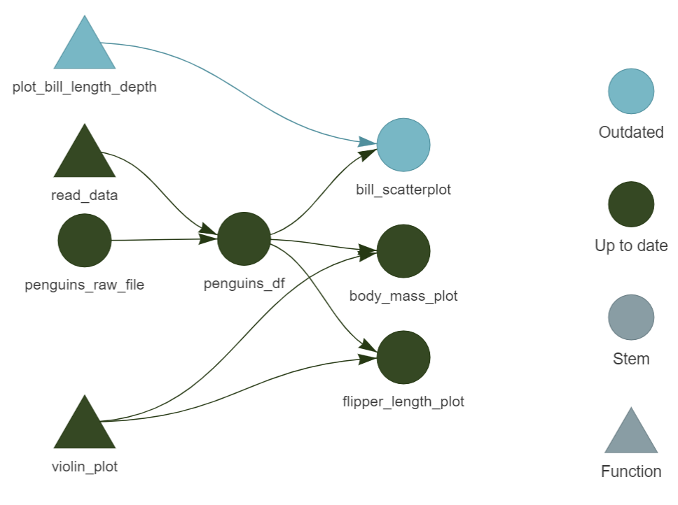

## Change in a step

```r
targets::tar_make()
```

```
here() starts at C:/Users/hrpoab/Desktop/GitHub/palmerpenguins_analysis
v skipped target penguins_raw_file
v skipped target penguins_df
v skipped target body_mass_plot
> dispatched target bill_scatterplot
o completed target bill_scatterplot [0.35 seconds]
v skipped target flipper_length_plot
> ended pipeline [0.53 seconds]
```

## Change in a step

```r
targets::tar_read(bill_scatterplot)
```

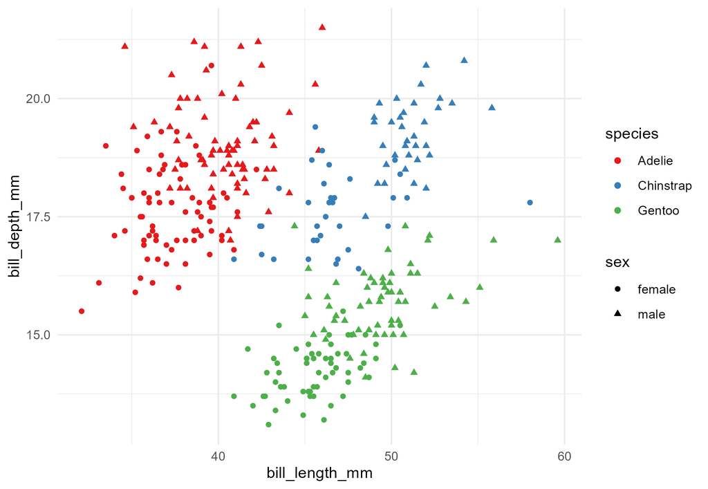

## Change in the data

> *Hi Olivia,*

> *Oopsie! We realised there was a mistake in the original data file. Here is the updated spreadsheet, could you re-run the analysis with this version?*

```r
targets::tar_visnetwork()
```

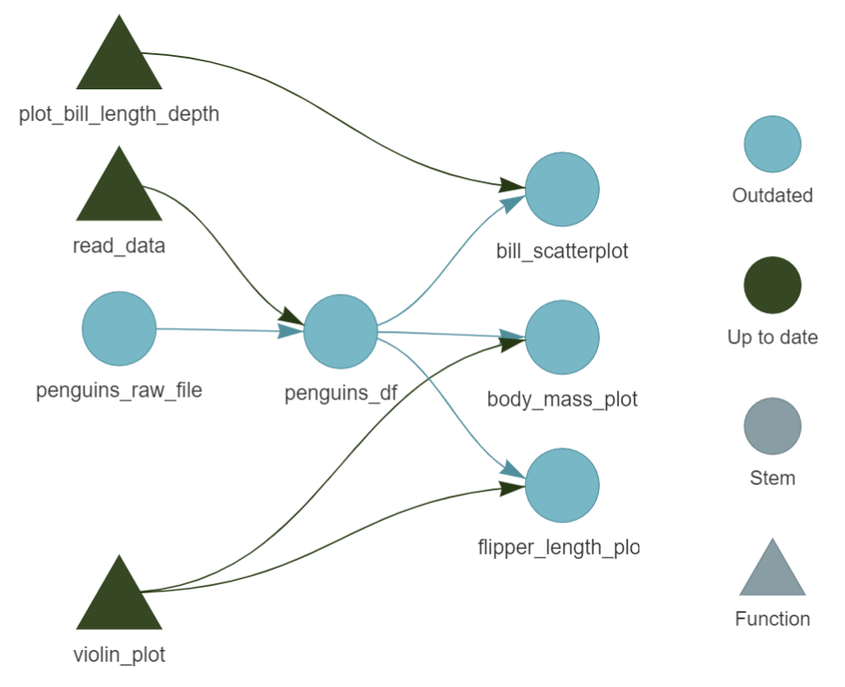

## Aside: where should my targets script live?

- default would be in the `_targets.R` file in the main directory
- to choose a custom folder and file name, need to specify targets configuration:

In the console, run (from main directory):

```r
targets::tar_config_set(script = "analysis/_targets.R", store = "analysis/_targets")
```

Will create a `_targets.yaml` file:

```
_target.yaml
```

```
main:
  script: analysis/_targets.R
  store: analysis/_targets
```

## Writing a report with Quarto

```
reports/palmerpenguins_report.qmd
```

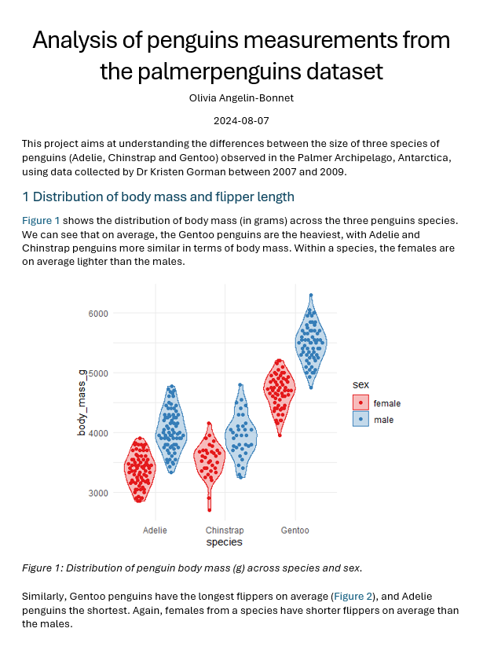

````markdown
---
title: |
  Analysis of penguins measurements from the
  palmerpenguins dataset
author: "Olivia Angelin-Bonnet"
date: today
format:
  docx:
    number-sections: true
---

```{r setup}
#| include: false

library(knitr)
opts_chunk$set(echo = FALSE)
```

This project aims at understanding the differences between
the size of three species of penguins (Adelie, Chinstrap
and Gentoo) observed in the Palmer Archipelago, Antarctica,
using data collected by Dr Kristen Gorman between 2007 and
2009.

## Distribution of body mass and flipper length

@fig-body-mass shows the distribution of body mass (in
grams) across the three penguins species. We can see
that on average, the Gentoo penguins are the heaviest,
with Adelie and Chinstrap penguins more similar in terms
of body mass. Within a species,
the females are on average lighter than the males.

```{r fig-body-mass}
#| fig-cap: "Distribution of penguin body mass ..."

# code for plot
```

Similarly, Gentoo penguins have the longest flippers on
average (@fig-flipper-length), and Adelie penguins the
shortest. Again, females from a species have shorter
flippers on average than the males.


```{r fig-flipper-length}
#| fig-cap: "Distribution of penguin flipper length ..."

# code for plot
```
````

## Quarto + `{targets}`

Two advantages of using a Quarto document alongside `{targets}`:

- can read in results from targets pipeline inside the report $\rightarrow$ no computation done during report generation
- can add the rendering of the report as a step in the pipeline $\rightarrow$ ensures that the report is always up-to-date

## Quarto + `{targets}`

Two steps to use the `{targets}` pipeline results in a Quarto document:

```
reports/palmerpenguins_report.qmd
```

````markdown
```{r setup}
#| include: false

library(knitr)

opts_chunk$set(echo = FALSE)
```

@fig-body-mass shows...

```{r fig-body-mass}
#| fig-cap: "Distribution ..."

# code for plot
```
````

## Quarto + `{targets}`

Two steps to use the `{targets}` pipeline results in a Quarto document:

- Make sure the report ‘sees’ the project root directory

```
reports/palmerpenguins_report.qmd
```

````markdown
```{r setup}
#| include: false

library(knitr)
library(here)

opts_chunk$set(echo = FALSE)
opts_knit$set(root.dir = here())
```

@fig-body-mass shows...

```{r fig-body-mass}
#| fig-cap: "Distribution ..."

# code for plot
```
````

## Quarto + `{targets}`

Two steps to use the `{targets}` pipeline results in a Quarto document:

- Make sure the report ‘sees’ the project root directory
- Read targets objects with `targets::tar_read()`

```
reports/palmerpenguins_report.qmd
```

````markdown
```{r setup}
#| include: false

library(knitr)
library(here)
library(targets)

opts_chunk$set(echo = FALSE)
opts_knit$set(root.dir = here())
```

@fig-body-mass shows...

```{r fig-body-mass}
#| fig-cap: "Distribution ..."

tar_read(body_mass_plot)
```
````

## Quarto + `{targets}`

Adding the Quarto report as a step in the pipeline (need `{tarchetypes}` and `{quarto}` packages installed):

```
analysis/_targets.R
```

```r
library(targets)

# ...

list(
  tar_target(penguins_raw_file, here("data/penguins_raw.csv"), format = "file"),

  tar_target(penguins_df, read_data(penguins_raw_file)),

  tar_target(body_mass_plot, violin_plot(penguins_df, body_mass_g)),

  tar_target(flipper_length_plot, violin_plot(penguins_df, flipper_length_mm)),

  tar_target(bill_scatterplot, plot_bill_length_depth(penguins_df))
)
```

## Quarto + `{targets}`

Adding the Quarto report as a step in the pipeline (need `{tarchetypes}` and `{quarto}` packages installed):

```
analysis/_targets.R
```

```r
library(targets)
library(tarchetypes)

# ...

list(
  tar_target(penguins_raw_file, here("data/penguins_raw.csv"), format = "file"),

  tar_target(penguins_df, read_data(penguins_raw_file)),

  tar_target(body_mass_plot, violin_plot(penguins_df, body_mass_g)),

  tar_target(flipper_length_plot, violin_plot(penguins_df, flipper_length_mm)),

  tar_target(bill_scatterplot, plot_bill_length_depth(penguins_df)),

  tar_quarto(report, here("reports/palmerpenguins_report.qmd"))
)
```

## Quarto + `{targets}`

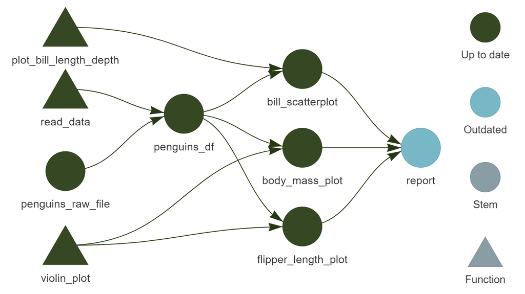

## Further reading

- The [blog post](https://olivia-angelin-bonnet.netlify.app/blog/2024-08-20-setting-up-r-project/) version of this talk 😄
- The [targets user manual](https://books.ropensci.org/targets/)
- The Carpentries Incubator’s [Introduction to targets](https://carpentries-incubator.github.io/targets-workshop/index.html) workshop
- Bruno Rodrigues’ book, [Building reproducible analytical pipelines with R](https://raps-with-r.dev/)

# Thank you for your attention!

olivia.angelin-bonnet@plantandfood.co.nz

## Presentation disclaimer

**Presentation for**  
Rladies Sydney, online, 7 April 2025

**Publication data:**  
Angelin-Bonnet O. April 2025. Reproducible analysis pipelines with `{targets}`. A Plant & Food Research presentation. SPTS No. 26935.

**Presentation prepared by:**  
Olivia Angelin-Bonnet  
Statistical Scientist, Data Science  
April 2025

**Presentation approved by:**  
Mark Wohlers  
Science Group Leader, Data Science  
April 2025

**For more information contact:**  
Olivia Angelin-Bonnet  
DDI: +64 6 355 6156  
Email: olivia.angelin-bonnet@plantandfood.co.nz

This report has been prepared by The New Zealand Institute for Plant and Food Research Limited (Plant & Food Research).  
Head Office: 120 Mt Albert Road, Sandringham, Auckland 1025, New Zealand, Tel: +64 9 925 7000, Fax: +64 9 925 7001.  
www.plantandfood.co.nz

#### COPYRIGHT

[figure not shown]